# minigame document

Fri 08 Apr 2022

[toc]

## 项目说明

#### 1. 介绍

 多服务版的游戏框架，主要有gate服务，mq，多个业务服务，缓存，数据库，etcd

#### 2. 项目文件目录说明

```go
├── **br.sh**        编译和启动server的脚本
├── **build.sh**    编译server的脚本
├── **clear.sh**    清理脚本
├── **debug.sh**    dlv启动脚本
├── **kill.sh**    杀死server的脚本
├── **component**    公共组件
│  ├── **base**    server基础
│  ├── **conf**    conf配置
│  ├── **db**        数据和缓存
│  ├── go.mod
│  ├── go.sum
│  └── **log**        log通用日志，可以打印到屏幕和文件中，日志文件按天切割
├── **log**        日志文件
├── **proto**        proto文件
│  ├── **auth**
│  ├── **email**
│  ├── **gate**
│  ├── go.mod
│  ├── go.sum
├── **proto.sh**    自动编译proto文件的脚本
├── Readme.md
├── **restart.sh**    重启server的脚本
├── **server**        所有的server存放目录
│  ├── **email**
│  ├── **gate**
│  ├── **hub**
│  └── **mq**
├── **start.sh**    启动server的脚本
└── **utils**        工具
├── go.mod
└── go.sum
```

#### 2. 项目架构

#### 4. 报文协议

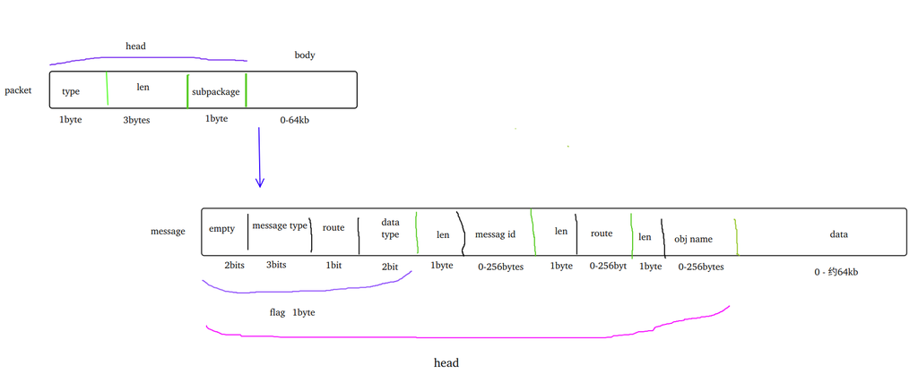

报文协议

- 报文分为2部分,packet和message
- packet
  - head

    5bytes
    - type

      1byte
      - Handshake = 0x01 客户端握手请求
      - HandshakeAck = 0x02 服务器握手ack
      - Heartbeat = 0x03 心跳
      - Data = 0x04 数据包
      - Kick = 0x05 客户端下线
    - len

      3bytes,body的长度
    - subpackage

      1byte，分包，但是没实现
  - body

    range 0-64kb

    二进制数据
  - message

    就是body
    - head

      range 1- xx bytes
      - flag
        - empty

          2bit
        - message type

          3bits

          ```go
          // Message types
          // s: server
          // c: client
          // who can send message type
          Request  Type = 0x00 // c
          Notify        = 0x01 // c
          Response      = 0x02 // s
          Push          = 0x03 // s
          Ack           = 0x04 // s,c
          ```

        - route

          1bit,是否压缩路由
        - date type

          2bits
    - len

      1byte,message id的长度
    - message id

      路由的内容，如果是字符串，它就是没有压缩的路由，如果是数字它就是压缩路由
    - len

      1byte,obj name的长度
    - obj name

      range 0-256bytes

      后面data里存的对象的名字
  - data

#### 5. 服务器与客户端交互流程

#### 6. 注意事项